# Ch 22 Text Mining

## 21.1 Trum tweets analysis

```r
library(tidyverse)
library(lubridate)
library(scales)
```

Get data from the website trumptwitterarchive.com. However, this data is already included in the `dslabs` package

```r
url <- 'http://www.trumptwitterarchive.com/data/realdonaldtrump/%s.json'
trump_tweets <- map(2009:2017, ~sprintf(url, .x)) %>%
  map_df(jsonlite::fromJSON, simplifyDataFrame = TRUE) %>%
  filter(!is_retweet & !str_detect(text, '^"')) %>%
  mutate(created_at = parse_date_time(created_at, orders = "a b! d! H!:M!:S! z!* Y!",tz="EST"))
trump_tweets
```

```r
library(dslabs)
data("trump_tweets")
head(trump_tweets)
```

|  | source | id_str | text | created_at | retweet_count | in_reply_to_user_id_str | favorite_count | is_retweet |
| --- | --- | --- | --- | --- | --- | --- | --- | --- |
| 1 | Twitter Web Client | 6971079756 | From Donald Trump: Wishing everyone a wonderful holiday & a happy, healthy, prosperous New Year. Lets think like champions in 2010! | 2009-12-23 12:38:18 | 28 | NA | 12 | FALSE |
| 2 | Twitter Web Client | 6312794445 | Trump International Tower in Chicago ranked 6th tallest building in world by Council on Tall Buildings & Urban Habitat http://bit.ly/sqvQq | 2009-12-03 14:39:09 | 33 | NA | 6 | FALSE |
| 3 | Twitter Web Client | 6090839867 | Wishing you and yours a very Happy and Bountiful Thanksgiving! | 2009-11-26 14:55:38 | 13 | NA | 11 | FALSE |
| 4 | Twitter Web Client | 5775731054 | Donald Trump Partners with TV1 on New Reality Series Entitled, Omarosa's Ultimate Merger: http://tinyurl.com/yk5m3lc | 2009-11-16 16:06:10 | 5 | NA | 3 | FALSE |
| 5 | Twitter Web Client | 5364614040 | --Work has begun, ahead of schedule, to build the greatest golf course in history: Trump International Scotland. | 2009-11-02 09:57:56 | 7 | NA | 6 | FALSE |
| 6 | Twitter Web Client | 5203117820 | --From Donald Trump: "Ivanka and Jareds wedding was spectacular, and they make a beautiful couple. Im a very proud father." | 2009-10-27 10:31:48 | 4 | NA | 5 | FALSE |

```r
names(trump_tweets)
```

```
## [1] "source"                  "id_str"
## [3] "text"                    "created_at"
## [5] "retweet_count"           "in_reply_to_user_id_str"
## [7] "favorite_count"          "is_retweet"
```

Tweet example.

```r
trump_tweets$text[16413] %>% str_wrap() %>% cat
```

```
## Great to be back in Iowa! #TBT with @JerryJrFalwell joining me in Davenport-
## this past winter. #MAGA https://t.co/A5IF0QHnic
```

Which device was used for the twitter account?

```r
trump_tweets %>% count(source) %>% arrange(desc(n)) #%>% head(5)
```

| source | n |
| --- | --- |
| Twitter Web Client | 10718 |
| Twitter for Android | 4652 |
| Twitter for iPhone | 3962 |
| TweetDeck | 468 |
| TwitLonger Beta | 288 |
| Instagram | 133 |
| Media Studio | 114 |
| Facebook | 104 |
| Twitter Ads | 96 |
| Twitter for BlackBerry | 78 |

[output cut: 9 more lines]

Focus on time of the campaign.

```r
campaign_tweets <- trump_tweets %>%
  extract(source, "source", "Twitter for (.*)") %>%
  filter(source %in% c("Android", "iPhone") &
           created_at >= ymd("2015-06-17") &
           created_at < ymd("2016-11-08")) %>%
  filter(!is_retweet) %>%
  arrange(created_at)
count(campaign_tweets)
```

| n |
| --- |
| 3950 |

Plot the divices Android and iPhone versus time.

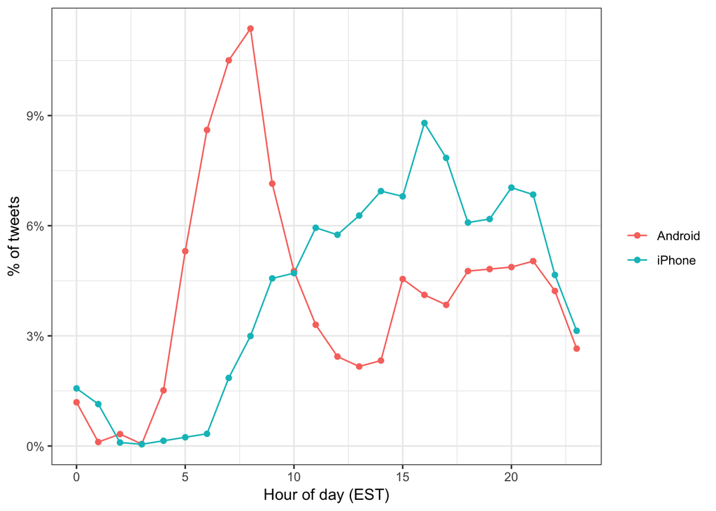

```r
ds_theme_set()
campaign_tweets %>%
  mutate(hour = hour(with_tz(created_at, "EST"))) %>%
  count(source, hour) %>%
  group_by(source) %>%
  mutate(percent = n / sum(n)) %>%
  ungroup %>%
  ggplot(aes(hour, percent, color = source)) +
  geom_line() +
  geom_point() +
  scale_y_continuous(labels = percent_format()) +
  labs(x = "Hour of day (EST)", y = "% of tweets", color = "")
```

## 21.2 Text as data

Example for the `tidytext` package.

```r
library(tidyverse)
library(tidytext)
poem <- c("Roses are red,", "Violets are blue,", "Sugar is sweet,", "And so are you.")
example <- data_frame(line = c(1, 2, 3, 4), text = poem)
example
```

| line | text |
| --- | --- |
| 1 | Roses are red, |
| 2 | Violets are blue, |
| 3 | Sugar is sweet, |
| 4 | And so are you. |

```r
example %>% unnest_tokens(word, text)
```

| line | word |
| --- | --- |
| 1 | roses |
| 1 | are |
| 1 | red |
| 2 | violets |
| 2 | are |
| 2 | blue |
| 3 | sugar |
| 3 | is |
| 3 | sweet |
| 4 | and |

[output cut: 3 more lines]

```r
i <- 3008
campaign_tweets$text[i]  %>% str_wrap() %>% cat()
```

```
## Great to be back in Iowa! #TBT with @JerryJrFalwell joining me in Davenport-
## this past winter. #MAGA https://t.co/A5IF0QHnic
```

Using an example tweet we can prepare the general extraction process.

```r
pattern <- "([^A-Za-z\\d#@']|'(?![A-Za-z\\d#@]))"
campaign_tweets[i,] %>%
mutate(text = str_replace_all(text, "https://t.co/[A-Za-z\\d]+|&amp;", ""))  %>%
unnest_tokens(word, text, token = "regex", pattern = pattern) %>% pull(word)
```

```
##  [1] "great"           "to"              "be"
##  [4] "back"            "in"              "iowa"
##  [7] "#tbt"            "with"            "@jerryjrfalwell"
## [10] "joining"         "me"              "in"
## [13] "davenport"       "this"            "past"
## [16] "winter"          "#maga"
```

Furthermore, we will use the object `stop_words` in order to remove all stop word like “a” or “the”. Also, numbers like years should be removed as well `str_detect(word, "^\\d+$")`.

```r
tweet_words <- campaign_tweets %>%
  mutate(text = str_replace_all(text, "https://t.co/[A-Za-z\\d]+|&amp;", ""))  %>%
  unnest_tokens(word, text, token = "regex", pattern = pattern) %>%
  filter(!word %in% stop_words$word &  !str_detect(word, "^\\d+$")) %>%
  mutate(word = str_replace(word, "^'", ""))
tweet_words %>% head()
```

|  | source | id_str | created_at | retweet_count | in_reply_to_user_id_str | favorite_count | is_retweet | word |
| --- | --- | --- | --- | --- | --- | --- | --- | --- |
| 1 | Android | 612063082186174464 | 2015-06-19 20:03:05 | 166 | NA | 348 | FALSE | @danaperino |
| 2 | Android | 612063082186174464 | 2015-06-19 20:03:05 | 166 | NA | 348 | FALSE | beg |
| 3 | Android | 612063082186174464 | 2015-06-19 20:03:05 | 166 | NA | 348 | FALSE | tweet |
| 4 | Android | 612063082186174464 | 2015-06-19 20:03:05 | 166 | NA | 348 | FALSE | endorsement |
| 5 | Android | 612063082186174464 | 2015-06-19 20:03:05 | 166 | NA | 348 | FALSE | book |
| 6 | Android | 612063082186174464 | 2015-06-19 20:03:05 | 166 | NA | 348 | FALSE | launched |

```r
tweet_words %>%
  count(word) %>%
  arrange(desc(n)) %>%
  head()
```

| word | n |
| --- | --- |
| #trump2016 | 415 |
| hillary | 409 |
| people | 304 |
| #makeamericagreatagain | 296 |
| america | 255 |
| clinton | 244 |

Which words are more likely to be tweeted from an iPhone device or an Android. The **odds ratio** summary statistics is used for that purpuse. I.e. for each device we compute the ratio that a word comes from an Android device and not from an iPhone. The shift factor **0.5** is used because most of the values evalute to zero.

```r
android_iphone_or <- tweet_words %>% count(word,source) %>% spread(source, n, fill=0) %>%
  mutate(sumA = sum(Android) - Android + 0.5) %>%
  mutate(sumP = sum(iPhone) - iPhone + 0.5) %>%
  mutate(devA = (Android + 0.5) / sumA) %>%
  mutate(devP = (iPhone + 0.5) / sumP) %>%
  mutate(or = devA/devP)
```

Evaluate the results. Filter the number of counted words to be larger then 100 in order to remove all low frequency words.

```r
android_iphone_or %>% filter(Android+iPhone > 100) %>% arrange(desc(or))
```

| word | Android | iPhone | sumA | sumP | devA | devP | or |
| --- | --- | --- | --- | --- | --- | --- | --- |
| @cnn | 104 | 18 | 15725.5 | 13784.5 | 6.645258e-03 | 0.001342087 | 4.951435395 |
| bad | 104 | 26 | 15725.5 | 13776.5 | 6.645258e-03 | 0.001923565 | 3.454656330 |
| crooked | 157 | 49 | 15672.5 | 13753.5 | 1.004945e-02 | 0.003599084 | 2.792224365 |
| ted | 85 | 28 | 15744.5 | 13774.5 | 5.430468e-03 | 0.002069041 | 2.624630823 |
| interviewed | 76 | 25 | 15753.5 | 13777.5 | 4.856064e-03 | 0.001850844 | 2.623702669 |
| media | 77 | 26 | 15752.5 | 13776.5 | 4.919854e-03 | 0.001923565 | 2.557674284 |
| cruz | 116 | 46 | 15713.5 | 13756.5 | 7.414007e-03 | 0.003380220 | 2.193350283 |
| hillary | 290 | 119 | 15539.5 | 13683.5 | 1.869430e-02 | 0.008733146 | 2.140614127 |
| win | 74 | 30 | 15755.5 | 13772.5 | 4.728508e-03 | 0.002214558 | 2.135192446 |
| president | 84 | 35 | 15745.5 | 13767.5 | 5.366613e-03 | 0.002578536 | 2.081263102 |

[output cut: 20 more lines]

```r
android_iphone_or %>% filter(Android+iPhone > 100) %>% arrange(or)
```

| word | Android | iPhone | sumA | sumP | devA | devP | or |
| --- | --- | --- | --- | --- | --- | --- | --- |
| #makeamericagreatagain | 0 | 296 | 15829.5 | 13506.5 | 3.158659e-05 | 0.021952393 | 0.001438868 |
| #trump2016 | 3 | 412 | 15826.5 | 13390.5 | 2.211481e-04 | 0.030805422 | 0.007178869 |
| join | 1 | 157 | 15828.5 | 13645.5 | 9.476577e-05 | 0.011542267 | 0.008210326 |
| tomorrow | 25 | 101 | 15804.5 | 13701.5 | 1.613465e-03 | 0.007407948 | 0.217801814 |
| vote | 46 | 67 | 15783.5 | 13735.5 | 2.946115e-03 | 0.004914273 | 0.599501589 |
| america | 114 | 141 | 15715.5 | 13661.5 | 7.285801e-03 | 0.010357574 | 0.703427318 |
| tonight | 71 | 84 | 15758.5 | 13718.5 | 4.537234e-03 | 0.006159566 | 0.736615892 |
| iowa | 62 | 65 | 15767.5 | 13737.5 | 3.963850e-03 | 0.004767971 | 0.831349391 |
| poll | 117 | 103 | 15712.5 | 13699.5 | 7.478123e-03 | 0.007555020 | 0.989821637 |
| trump | 112 | 92 | 15717.5 | 13710.5 | 7.157627e-03 | 0.006746654 | 1.060915059 |

[output cut: 20 more lines]

Next, seniments are used to correlate the words to a tone of the message. The package `tidytext` contains the `sentiment` object.

```r
nrc <- sentiments %>% filter(lexicon == "nrc") %>%select(word, sentiment)
tweet_words %>% inner_join(nrc, by = "word") %>%  select(source, word, sentiment) %>% sample_n(5)
```

|  | source | word | sentiment |
| --- | --- | --- | --- |
| 11341 | iPhone | defy | surprise |
| 9417 | Android | bad | disgust |
| 8835 | Android | genius | positive |
| 10720 | iPhone | john | negative |
| 6861 | Android | failing | negative |

In the following analysis for each sentiment the number of words per device is aggregated.

```r
sentiment_counts <- tweet_words %>%
  left_join(nrc, by = "word") %>%
  count(source, sentiment) %>%
  spread(source, n) %>%
  mutate(sentiment = replace_na(sentiment, replace = "none"))
sentiment_counts
```

| sentiment | Android | iPhone |
| --- | --- | --- |
| anger | 965 | 527 |
| anticipation | 915 | 710 |
| disgust | 641 | 318 |
| fear | 802 | 486 |
| joy | 698 | 540 |
| negative | 1668 | 935 |
| positive | 1834 | 1497 |
| sadness | 907 | 514 |
| surprise | 530 | 365 |
| trust | 1253 | 1010 |

[output cut: 1 more lines]

Next, we can compute the proportion (probability) of being in one device and not in the other.

```r
sentiment_counts %>%
  mutate(Android = Android / (sum(Android) - Android) ,
         iPhone = iPhone / (sum(iPhone) - iPhone),
         or = Android/iPhone) %>%
  arrange(desc(or))
```

| sentiment | Android | iPhone | or |
| --- | --- | --- | --- |
| disgust | 0.03038635 | 0.01835710 | 1.6552915 |
| anger | 0.04645901 | 0.03079350 | 1.5087275 |
| negative | 0.08311740 | 0.05596792 | 1.4850902 |
| sadness | 0.04354506 | 0.03001109 | 1.4509654 |
| fear | 0.03831088 | 0.02832993 | 1.3523111 |
| surprise | 0.02499293 | 0.02112758 | 1.1829529 |
| joy | 0.03317806 | 0.03157710 | 1.0507000 |
| anticipation | 0.04394602 | 0.04193491 | 1.0479577 |
| trust | 0.06117268 | 0.06072996 | 1.0072899 |
| positive | 0.09215154 | 0.09272795 | 0.9937839 |

[output cut: 1 more lines]

Validating the results by asking if the differences in the device assinings are just by chance. For this a confidence interval is computed which is further explained in the chapter “Statistical Inference”.

```r
library(broom)
log_or <- sentiment_counts %>%
  mutate(log_or = log((Android / (sum(Android) - Android)) /
      (iPhone / (sum(iPhone) - iPhone))),
          se = sqrt(1/Android + 1/(sum(Android) - Android) +
                      1/iPhone + 1/(sum(iPhone) - iPhone)),
          conf.low = log_or - qnorm(0.975)*se,
          conf.high = log_or + qnorm(0.975)*se) %>%
  arrange(desc(log_or))
log_or
```

| sentiment | Android | iPhone | log_or | se | conf.low | conf.high |
| --- | --- | --- | --- | --- | --- | --- |
| disgust | 641 | 318 | 0.503977127 | 0.06935307 | 0.36804761 | 0.63990664 |
| anger | 965 | 527 | 0.411266612 | 0.05513963 | 0.30319493 | 0.51933829 |
| negative | 1668 | 935 | 0.395475483 | 0.04217497 | 0.31281405 | 0.47813691 |
| sadness | 907 | 514 | 0.372229104 | 0.05616457 | 0.26214858 | 0.48230963 |
| fear | 802 | 486 | 0.301815029 | 0.05839998 | 0.18735318 | 0.41627688 |
| surprise | 530 | 365 | 0.168013748 | 0.06878633 | 0.03319502 | 0.30283247 |
| joy | 698 | 540 | 0.049456578 | 0.05822822 | -0.06466864 | 0.16358179 |
| anticipation | 915 | 710 | 0.046843264 | 0.05107288 | -0.05325773 | 0.14694426 |
| trust | 1253 | 1010 | 0.007263495 | 0.04355609 | -0.07810488 | 0.09263187 |
| positive | 1834 | 1497 | -0.006235497 | 0.03640670 | -0.07759131 | 0.06512032 |

[output cut: 1 more lines]

```r
log_or_reorder <- log_or %>%  mutate(sentiment = reorder(sentiment, log_or))
log_or_reorder
```

| sentiment | Android | iPhone | log_or | se | conf.low | conf.high |
| --- | --- | --- | --- | --- | --- | --- |
| disgust | 641 | 318 | 0.503977127 | 0.06935307 | 0.36804761 | 0.63990664 |
| anger | 965 | 527 | 0.411266612 | 0.05513963 | 0.30319493 | 0.51933829 |
| negative | 1668 | 935 | 0.395475483 | 0.04217497 | 0.31281405 | 0.47813691 |
| sadness | 907 | 514 | 0.372229104 | 0.05616457 | 0.26214858 | 0.48230963 |
| fear | 802 | 486 | 0.301815029 | 0.05839998 | 0.18735318 | 0.41627688 |
| surprise | 530 | 365 | 0.168013748 | 0.06878633 | 0.03319502 | 0.30283247 |
| joy | 698 | 540 | 0.049456578 | 0.05822822 | -0.06466864 | 0.16358179 |
| anticipation | 915 | 710 | 0.046843264 | 0.05107288 | -0.05325773 | 0.14694426 |
| trust | 1253 | 1010 | 0.007263495 | 0.04355609 | -0.07810488 | 0.09263187 |
| positive | 1834 | 1497 | -0.006235497 | 0.03640670 | -0.07759131 | 0.06512032 |

[output cut: 1 more lines]

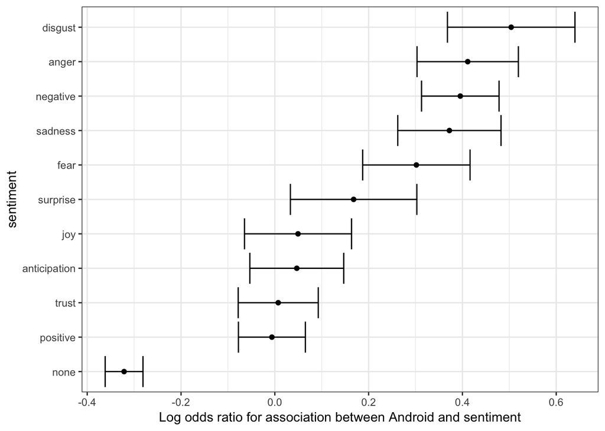

```r
log_or_reorder %>%
  ggplot(aes(x = sentiment, ymin = conf.low, ymax = conf.high)) +
  geom_errorbar() +
  geom_point(aes(sentiment, log_or)) +
  ylab("Log odds ratio for association between Android and sentiment") +
  coord_flip()
```

By looking back at the words to sentiment join, we can derive which word specificaly drives the sentiments.

```r
device_sentiment <- android_iphone_or %>% inner_join(nrc, by = "word") %>%
  mutate(sentiment = factor(sentiment, levels = log_or$sentiment)) %>%
  mutate(log_or = log(or)) %>%
  filter(Android + iPhone > 10 & abs(log_or)>1) %>%
  mutate(word = reorder(word, log_or))
device_sentiment
```

| word | Android | iPhone | sumA | sumP | devA | devP | or | sentiment | log_or |
| --- | --- | --- | --- | --- | --- | --- | --- | --- | --- |
| bad | 104 | 26 | 15725.5 | 13776.5 | 6.645258e-03 | 1.923565e-03 | 3.454656330 | anger | 1.239723 |
| bad | 104 | 26 | 15725.5 | 13776.5 | 6.645258e-03 | 1.923565e-03 | 3.454656330 | disgust | 1.239723 |
| bad | 104 | 26 | 15725.5 | 13776.5 | 6.645258e-03 | 1.923565e-03 | 3.454656330 | fear | 1.239723 |
| bad | 104 | 26 | 15725.5 | 13776.5 | 6.645258e-03 | 1.923565e-03 | 3.454656330 | negative | 1.239723 |
| bad | 104 | 26 | 15725.5 | 13776.5 | 6.645258e-03 | 1.923565e-03 | 3.454656330 | sadness | 1.239723 |
| badly | 34 | 3 | 15795.5 | 13799.5 | 2.184166e-03 | 2.536324e-04 | 8.611543975 | negative | 2.153104 |
| badly | 34 | 3 | 15795.5 | 13799.5 | 2.184166e-03 | 2.536324e-04 | 8.611543975 | sadness | 2.153104 |
| beach | 3 | 8 | 15826.5 | 13794.5 | 2.211481e-04 | 6.161876e-04 | 0.358897307 | joy | -1.024719 |
| biased | 25 | 7 | 15804.5 | 13795.5 | 1.613465e-03 | 5.436555e-04 | 2.967806637 | negative | 1.087823 |
| boring | 16 | 3 | 15813.5 | 13799.5 | 1.043412e-03 | 2.536324e-04 | 4.113876480 | negative | 1.414366 |

[output cut: 81 more lines]

And with a grafical representation. Negative values mean that the device used was an iPhone and positive values an Android device.

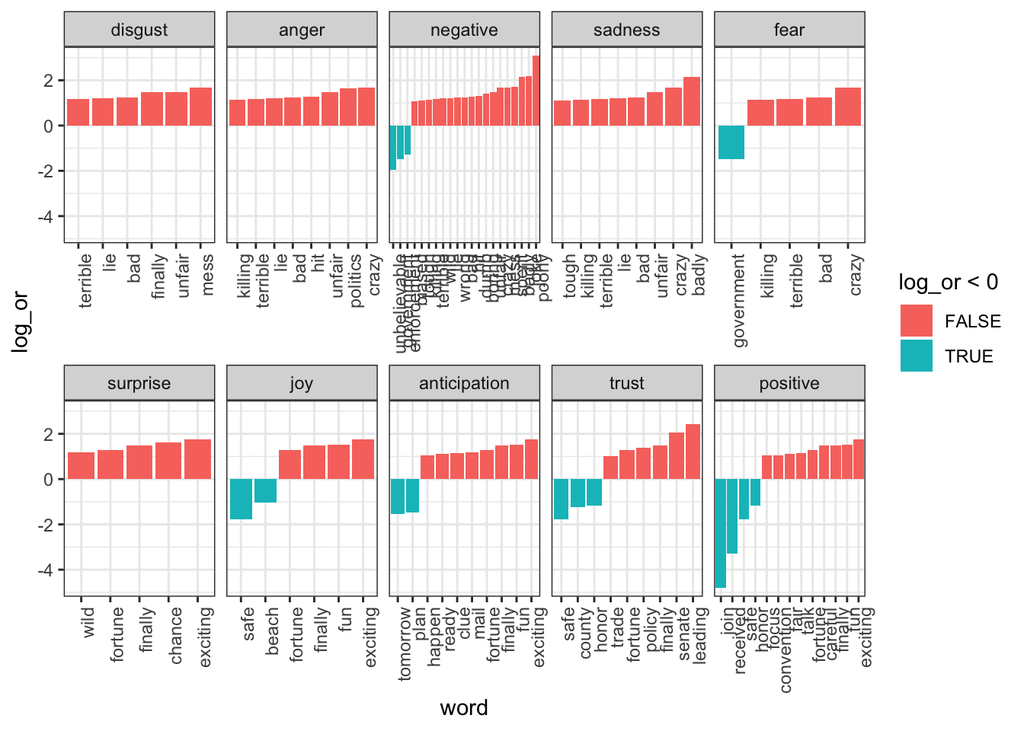

```r
device_sentiment %>%
  ggplot(aes(word, log_or, fill = log_or < 0)) +
  facet_wrap(~sentiment, scales = "free_x", nrow = 2) +
  geom_bar(stat="identity") +
  theme(axis.text.x = element_text(angle = 90, hjust = 1))
```